## 데이터 결합

서로 다른 데이터프레임에 저장된 데이터를 합쳐서 하나의 데이터프레임으로 만들어 사용하는 것을 데이터 결합(Merge)이라고 한다. R에서 데이터를 결합하는 방법은 데이터 조인과 데이터 바인딩으로 구분된다.

#### 데이터 조인

데이터 조인은 서로 다른 데이터프레임에서 같은 값을 가진 열의 데이터를 사용하여 두개의 데이터프레임을 하나로 묶어주는 방법이다. 조인의 기준을 어디에 두느냐에 따라 왼쪽 조인(`left_join()`), 오른쪽 조인(`right_join()`), 내부 조인(`inner_join()`), 전체 조인(`full_Join()`)으로 구분된다.

- 왼쪽 조인 : 조인의 기준을 왼쪽 데이터프레임에 두고 왼쪽 데이터 프레임에 대응되는 오른쪽 데이터프레임의 값을 가져온다. 만약 왼쪽 데이터프레임에 대응되는 오른쪽 데이터프레임의 값이 없다면 NA값을 넣어준다.
- 오른쪽 조인 : 조인의 기준을 오른쪽 데이터프레임에 두고 오른쪽 데이터 프레임에 대응되는 왼쪽 데이터프레임의 값을 가져온다. 만약 오른쪽 데이터프레임에 대응되는 왼쪽 데이터프레임의 값이 없다면 NA값을 넣어준다.
- 내부 조인 : 두개의 데이터프레임의 결합 기준이 되는 데이터가 일치하는 데이터만 조인된다. 앞의 왼쪽 조인, 오른쪽 조인에서 NA값을 제거하는 방법이다.
- 전체 조인 : 왼쪽 조인과 오른쪽 조인을 모두 사용하는 방법으로 왼쪽 조인으로 발생되는 NA와 오른쪽 조인으로 발생되는 NA를 모두 생성하는 방법이다.

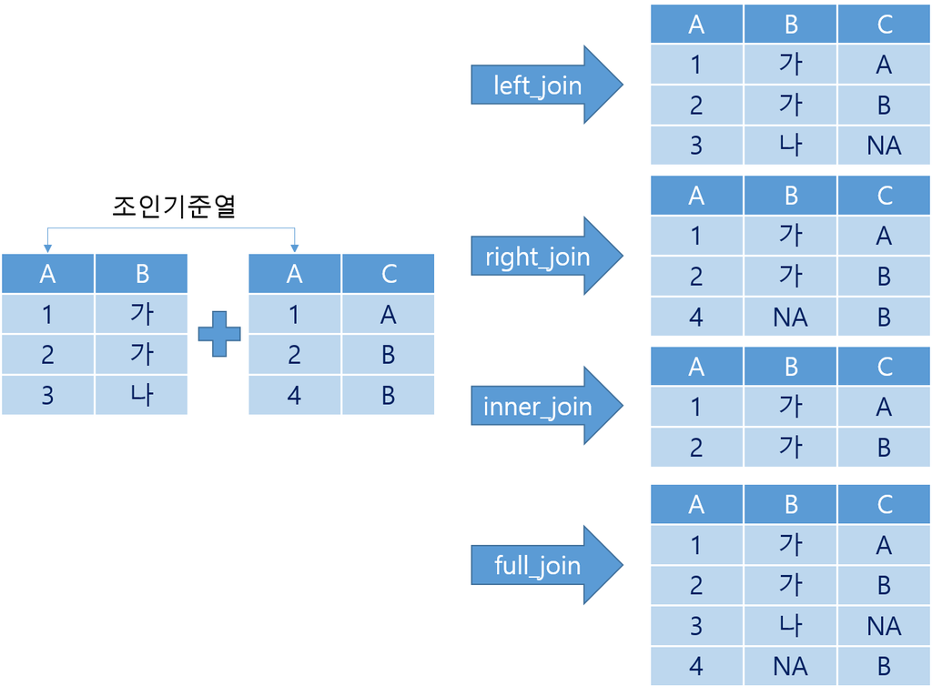

left_join(x, y, by, copy = FALSE, suffix = c(“.x”, “.y”), …, keep = FALSE)

right_join(x, y, by, copy = FALSE, suffix = c(“.x”, “.y”), …, keep = FALSE)

inner_join(x, y, by, copy = FALSE, suffix = c(“.x”, “.y”), …, keep = FALSE)

full_join(x, y, by, copy = FALSE, suffix = c(“.x”, “.y”), …, keep = FALSE)  
- x : 왼쪽 데이터프레임  
- y : 오른쪽 데이터프레임  
- by : 조인의 기준이 될 열

```r
## 조인을 위한 데이터프레임 생성
df_join1 <- data.frame(A = c(1, 2, 3), B = c('가', '가', '나'))

df_join2 <- data.frame(A = c(1, 2, 4), C = c('A', 'B', 'B'))

## df_join1을 기준으로 한 조인
left_join(df_join1, df_join2, by = 'A')
```

```
##   A  B    C
## 1 1 가    A
## 2 2 가    B
## 3 3 나 <NA>
```

```r
## df_join2을 기준으로 한 조인
right_join(df_join1, df_join2, by = 'A')
```

```
##   A    B C
## 1 1   가 A
## 2 2   가 B
## 3 4 <NA> B
```

```r
## 양쪽 데이터 모두 해당하는 조인
inner_join(df_join1, df_join2, by = 'A')
```

```
##   A  B C
## 1 1 가 A
## 2 2 가 B
```

```r
## 전체 데이터에 대한 조인
full_join(df_join1, df_join2, by = 'A')
```

```
##   A    B    C
## 1 1   가    A
## 2 2   가    B
## 3 3   나 <NA>
## 4 4 <NA>    B
```

#### 데이터 바인딩

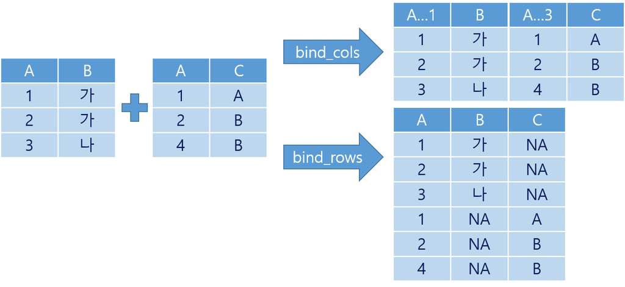

bind_cols(…, .id = NULL)

bind_rows(…, .name_repair = c(“unique”, “universal”, “check_unique”, “minimal”))  
- … : 바인딩 할 데이터프레임  
- .id : 데이터프레임 id

```r
## 데이터 바인딩을 위한 데이터프레임 생성
df_bind1 <- data.frame(A = c(1, 2, 3), B = c('가', '가', '나'))

df_bind2 <- data.frame(A = c(1, 2, 4), C = c('A', 'B', 'B'))

## 열 방향 데이터 바인딩
bind_cols(df_bind1, df_bind2)
```

```
##   A...1  B A...3 C
## 1     1 가     1 A
## 2     2 가     2 B
## 3     3 나     4 B
```

```r
## 행 방향 데이터 바인딩
bind_rows(df_bind1, df_bind2)
```

```
##   A    B    C
## 1 1   가 <NA>
## 2 2   가 <NA>
## 3 3   나 <NA>
## 4 1 <NA>    A
## 5 2 <NA>    B
## 6 4 <NA>    B
```